# TEMPEST: Porewater ICP

Run 1 - 2026/04/15

2023-2025 Samples

2026-08-26

#SET UP

#USEFUL FUNCTIONS

# April 15, 2026 - Run 1

## Metal Standard Curve Checks

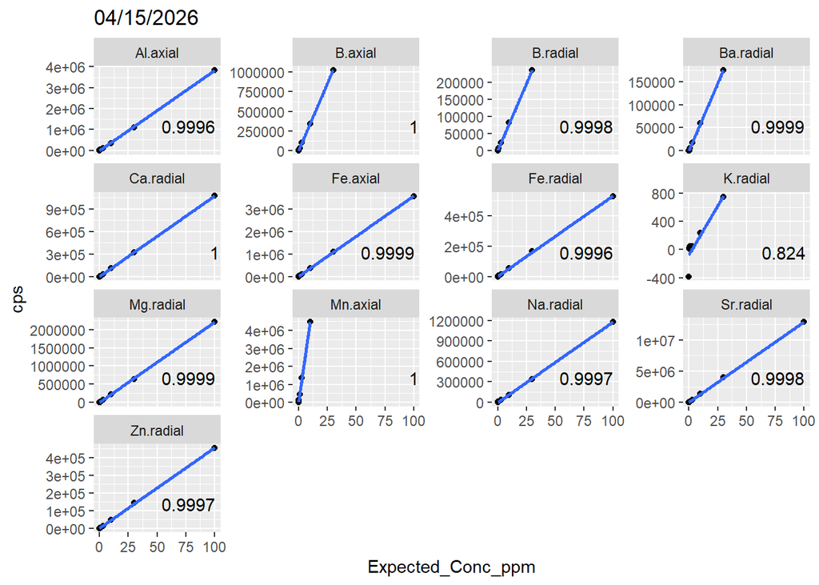

**TABLE OF CALIBRATION CURVE VALUES**

Red values are <0.999

| Element | slope | intercept | R2 | Run_Date |
| --- | --- | --- | --- | --- |
| Al.axial | 38386.58580 | -13666.69290 | 0.99965 | 04/15/2026 |
| B.axial | 34278.00811 | -667.69856 | 0.99999 | 04/15/2026 |
| B.radial | 7862.76318 | 139.60306 | 0.99979 | 04/15/2026 |
| Ba.radial | 5861.03563 | 110.51977 | 0.99987 | 04/15/2026 |
| Ca.radial | 10705.52879 | 1734.13740 | 0.99996 | 04/15/2026 |
| Fe.axial | 35803.13917 | 5713.34837 | 0.99991 | 04/15/2026 |
| Fe.radial | 5295.37234 | 1033.26936 | 0.99961 | 04/15/2026 |
| K.radial | 27.83381 | -73.33325 | 0.82395 | 04/15/2026 |
| Mg.radial | 22185.01099 | -3905.83891 | 0.99992 | 04/15/2026 |
| Mn.axial | 447225.58425 | 3315.42489 | 0.99996 | 04/15/2026 |
| Na.radial | 11822.94771 | -4536.13367 | 0.99974 | 04/15/2026 |
| Sr.radial | 128612.75663 | 26943.74101 | 0.99977 | 04/15/2026 |
| Zn.radial | 4561.27278 | 757.82091 | 0.99967 | 04/15/2026 |

## P, S, and Si Standard Curve Checks

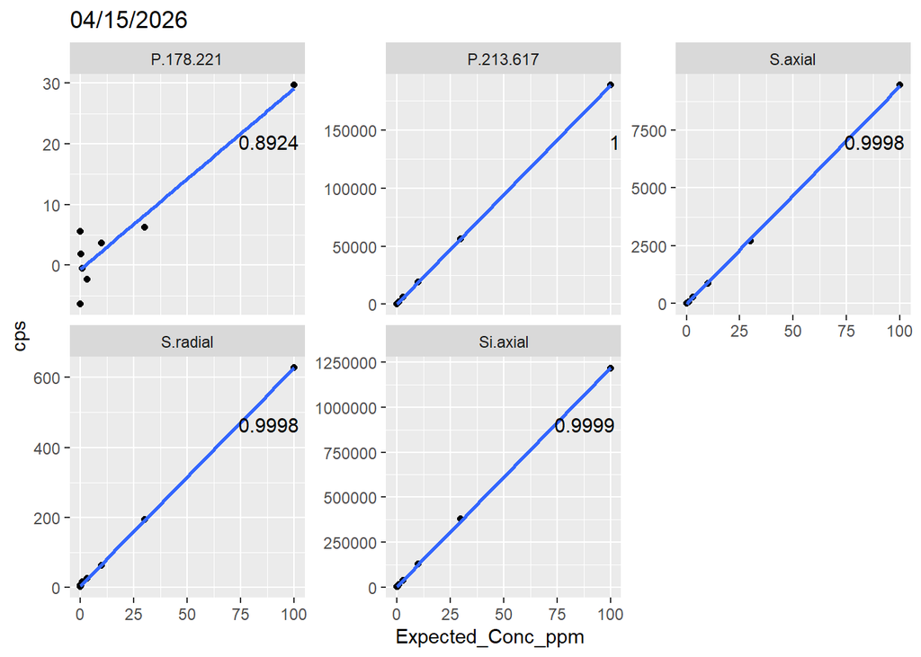

**TABLE OF CALIBRATION CURVE VALUES**

Red values are <0.999

| Element | slope | intercept | R2 | Run_Date |
| --- | --- | --- | --- | --- |
| P.178.221 | 0.29812 | -0.66984 | 0.89239 | 04/15/2026 |
| P.213.617 | 1884.27106 | 137.62960 | 0.99998 | 04/15/2026 |
| S.axial | 94.34777 | -23.70829 | 0.99977 | 04/15/2026 |
| S.radial | 6.22249 | 5.05438 | 0.99981 | 04/15/2026 |
| Si.axial | 12162.13940 | 2745.13143 | 0.99989 | 04/15/2026 |

#Import sample data

## Counts

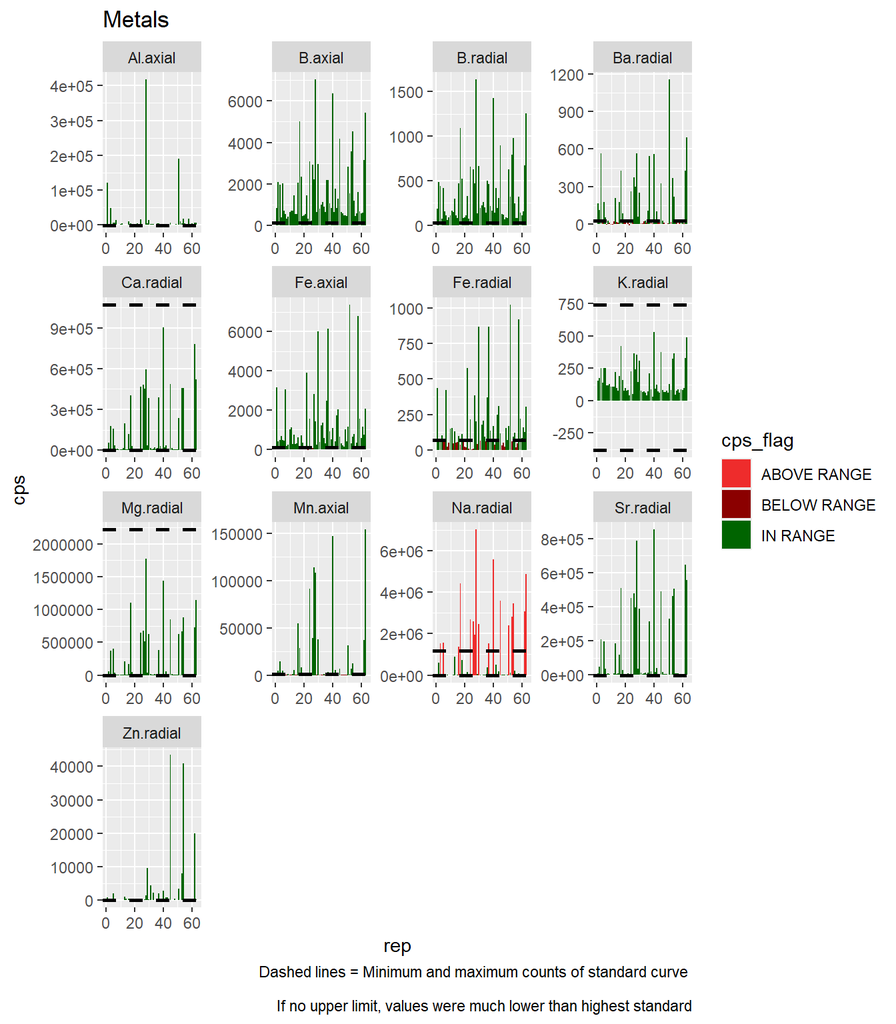

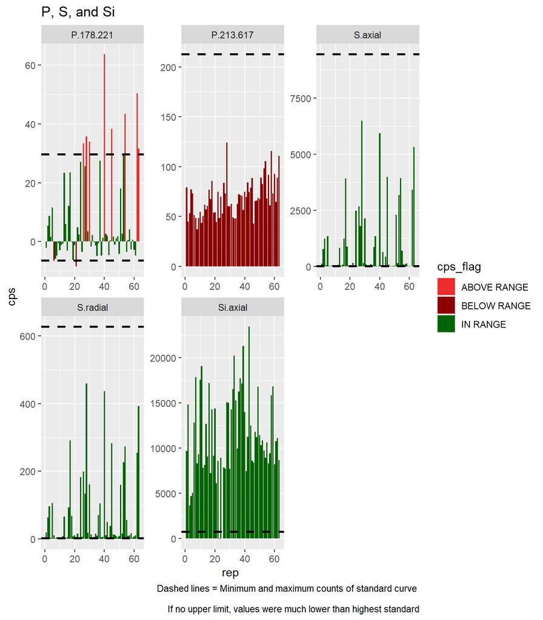

Red elements had <80% of samples within range of standard curve

| Element | Pass_percent | range_flag |
| --- | --- | --- |
| Al.axial | 100.0 | PASS |
| B.axial | 100.0 | PASS |
| B.radial | 100.0 | PASS |
| Ba.radial | 50.8 | FAIL |
| Ca.radial | 95.2 | PASS |
| Fe.axial | 92.1 | PASS |
| Fe.radial | 61.9 | FAIL |
| K.radial | 100.0 | PASS |
| Mg.radial | 100.0 | PASS |
| Mn.axial | 49.2 | FAIL |
| Na.radial | 73.0 | FAIL |
| P.178.221 | 84.1 | PASS |
| P.213.617 | 0.0 | FAIL |
| S.axial | 84.1 | PASS |
| S.radial | 95.2 | PASS |
| Si.axial | 96.8 | PASS |
| Sr.radial | 100.0 | PASS |
| Zn.radial | 95.2 | PASS |

## Asses Metal Check Standards

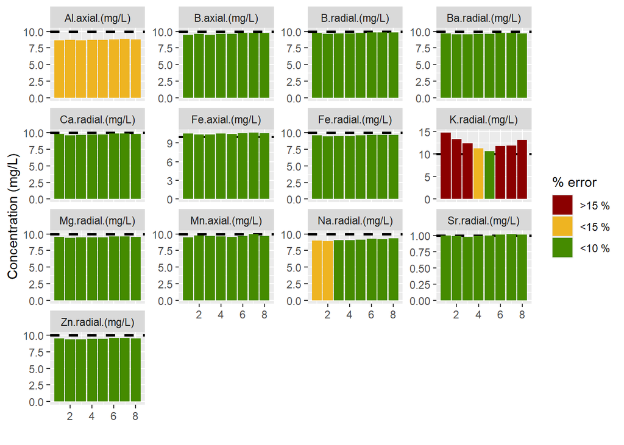

**LIST OF ELEMENTS WITH <80% OF CHECK STANDARDS WITHIN 15% OF EXPECTED CONCENTRATION - REASSESS**

| Element |
| --- |
| K.radial |

## Assess P, S, and Si Check Standards

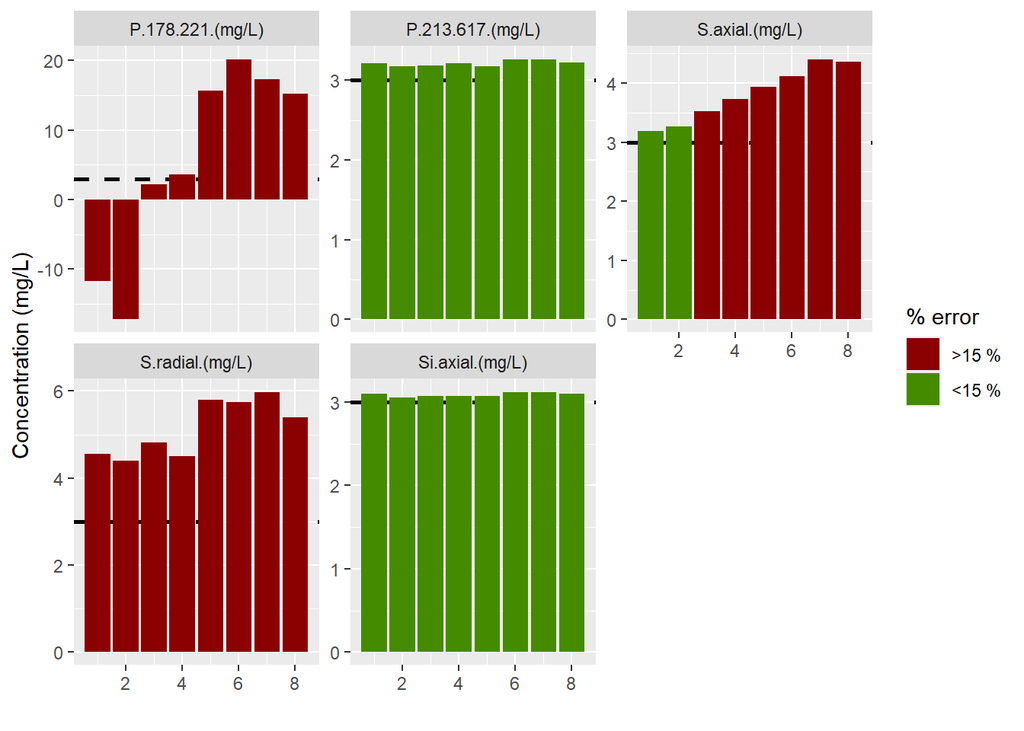

**LIST OF ELEMENTS WITH <80% OF CHECK STANDARDS WITHIN 15% OF EXPECTED CONCENTRATION - REASSESS**

| Element |
| --- |
| P.178.221 |
| S.axial |
| S.radial |

## Check Internal Standards

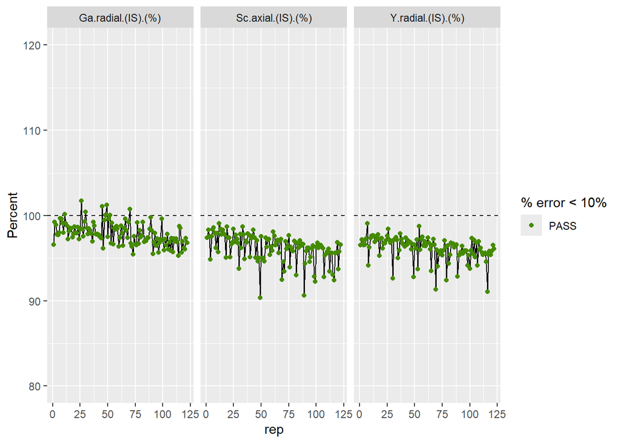

100 % of Internal Standards measurements are within 10% of 100

## Additional Checks

### NIST 1643f and Multi-elemental standard (QCS) are used as additional checks with a 10x dilution

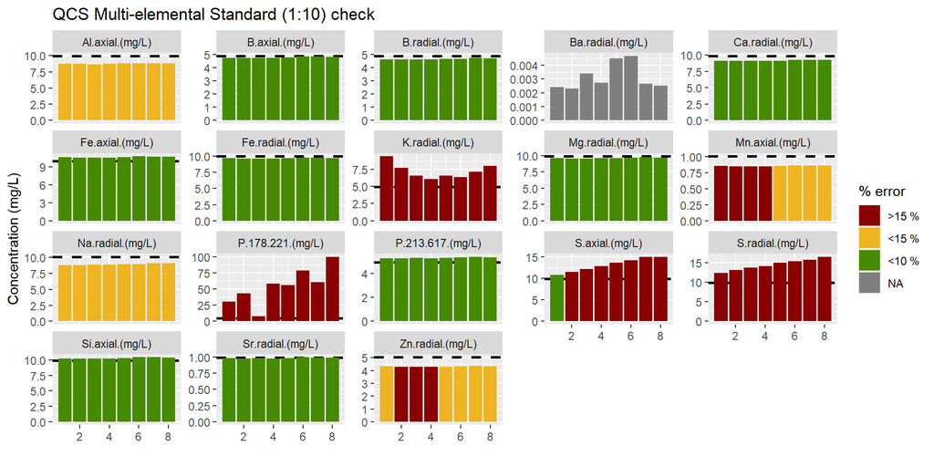

**LIST OF ELEMENTS WITH <80% OF CHECK STANDARDS WITHIN 15% OF EXPECTED CONCENTRATION - REASSESS**

| Element | Avg % Error |
| --- | --- |
| K.radial | 45.35 |
| Mn.axial | 14.85 |
| P.178.221 | 998.35 |
| S.axial | 33.03 |
| S.radial | 46.67 |
| Zn.radial | 14.47 |

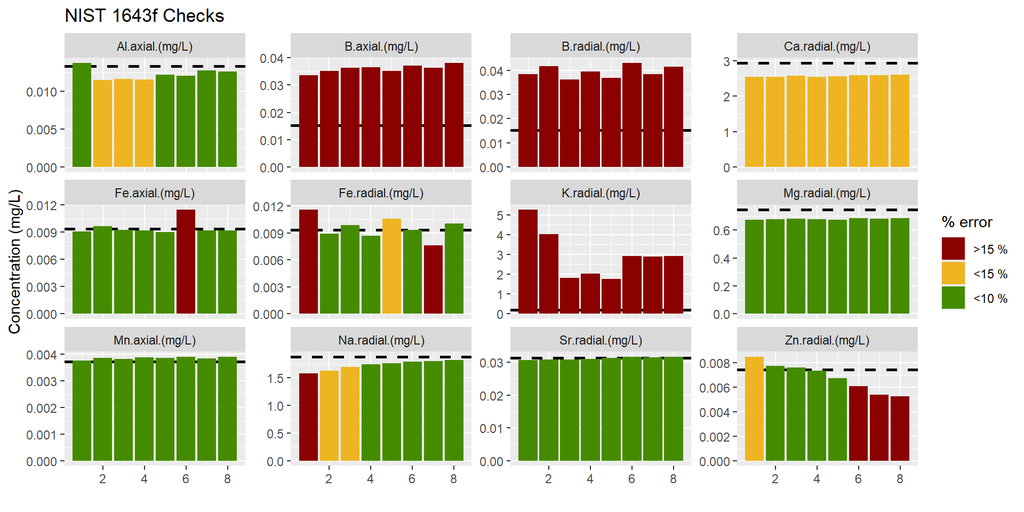

**LIST OF ELEMENTS WITH <80% OF NIST CHECKS WITHIN 15% OF EXPECTED CONCENTRATION - REASSESS**

| Element | Avg % Error |
| --- | --- |
| B.axial | 136.69 |
| B.radial | 159.18 |
| Fe.radial | 10.02 |
| K.radial | 1424.81 |
| Zn.radial | 13.13 |

### Duplicate samples

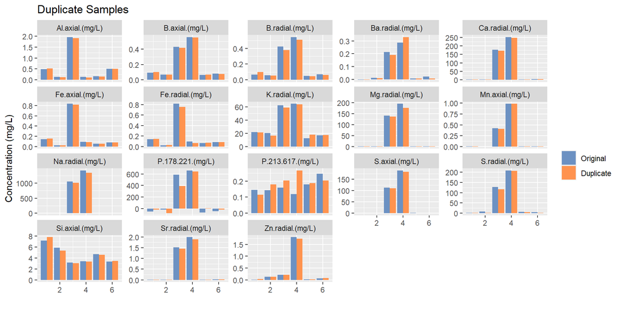

**LIST OF ELEMENTS WITH <80% OF DUPLICATE SAMPLES WITHIN 15% OF SAMPLE CONCENTRATION - REASSESS**

| Element | Avg % Difference |
| --- | --- |
| Ba.radial | 29.12 |
| Fe.radial | 12.36 |
| K.radial | 11.35 |
| P.178.221 | 90.61 |
| P.213.617 | 27.79 |
| S.axial | 33.99 |
| S.radial | 48.59 |
| Zn.radial | 24.56 |

### Sample Spikes

*Samples spiked with 0.2 mL of LFB (M10)*

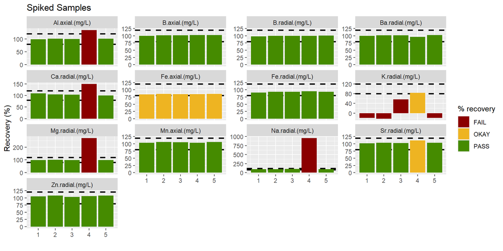

**LIST OF ELEMENTS WITH <80% OF SPIKED SAMPLES WITH 100 (+/- 20%) PERCENT RECOVERY - REASSESS**

| Element | Avg % Recovery |
| --- | --- |
| K.radial | 40.62 |

# **Summary of QA/QC Results**

*Red elements did not pass QA/QC Checks*

Element must pass either NIST or QCS checks AND check standards

| Element | Number of Checks | Fail (%) | Passed_checks | Failed_checks | QAQC |
| --- | --- | --- | --- | --- | --- |
| Al.axial | 6 | 0 | range, chk , NIST , QCS , dup , spk |  | PASS |
| B.axial | 6 | 17 | range, chk , QCS , dup , spk | NIST | PASS |
| B.radial | 6 | 17 | range, chk , QCS , dup , spk | NIST | PASS |
| Ba.radial | 4 | 50 | chk, spk | range, dup | FAIL |
| Ca.radial | 6 | 0 | range, chk , NIST , QCS , dup , spk |  | PASS |
| Fe.axial | 6 | 0 | range, chk , NIST , QCS , dup , spk |  | PASS |
| Fe.radial | 6 | 50 | chk, QCS, spk | range, NIST , dup | PASS |
| K.radial | 6 | 83 | range | chk , NIST, QCS , dup , spk | FAIL |
| Mg.radial | 6 | 0 | range, chk , NIST , QCS , dup , spk |  | PASS |
| Mn.axial | 6 | 33 | chk , NIST, dup , spk | range, QCS | PASS |
| Na.radial | 6 | 17 | chk , NIST, QCS , dup , spk | range | PASS |
| P.178.221 | 4 | 75 | range | chk, QCS, dup | FAIL |
| P.213.617 | 4 | 50 | chk, QCS | range, dup | PASS |
| S.axial | 4 | 75 | range | chk, QCS, dup | FAIL |
| S.radial | 4 | 75 | range | chk, QCS, dup | FAIL |
| Si.axial | 4 | 0 | range, chk , QCS , dup |  | PASS |
| Sr.radial | 6 | 0 | range, chk , NIST , QCS , dup , spk |  | PASS |
| Zn.radial | 6 | 50 | range, chk , spk | NIST, QCS , dup | FAIL |

# Sample Processing Steps

1. Sample concentrations were compared to blank concentrations. If sample concentration < blank concentration, then the sample concentration was set to zero.
2. Dilution factor was applied to each sample. In most cases, DF=5
3. Flags added to elments that had a poor standard curve.
4. Elements that did not pass QAQC were removed from the dataset
5. Removed samples that had low internal standards (<90%)
6. Column added to data listing elements that did not pass QAQC
7. Data exported to .csv

# Preliminary Plot of Data

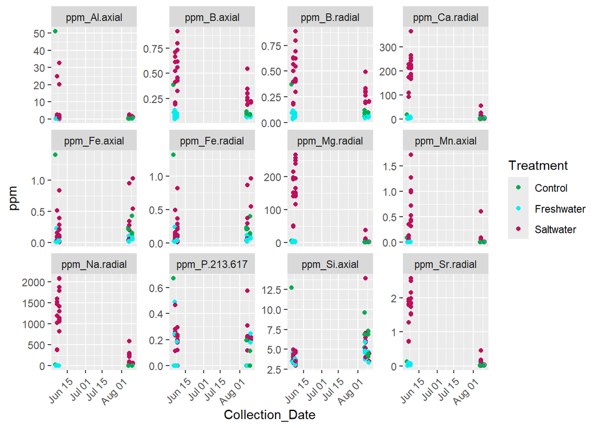